# CSDE Workshop: Introduction to R

## R data structures

There are 5 basic data structures in R, as shown in the graphic:

1. vector
2. matrix
3. array
4. data frame
5. list

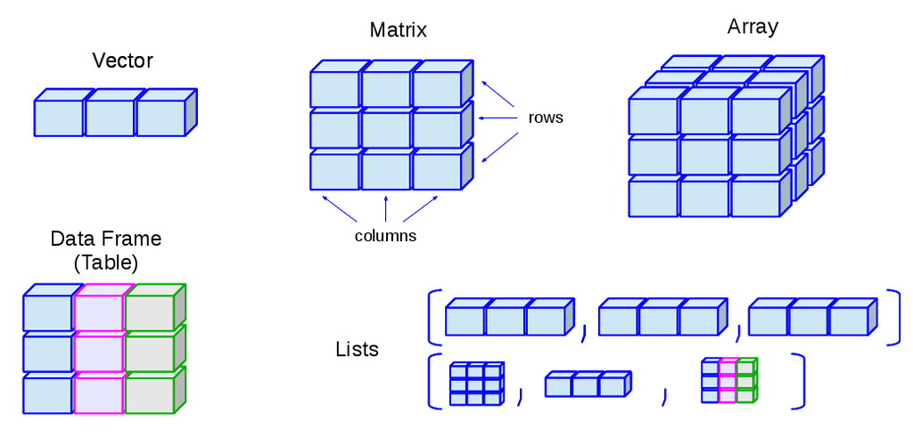

### Vector

A vector is an ordered set of elements of one or more elements of the same data type and are created using the `c()` constructor function. For example, a single value is a vector:

```r
# create a vector of length 1
a <- 1
is(a)
```

```
## [1] "numeric" "vector"
```

#### rep()

We can create a vector with repeated numbers.

```r
# see help(rep)

z <- rep(1,5)
z
```

```
## [1] 1 1 1 1 1
```

```r
q <- rep(c(1, 2), 5)
q
```

```
##  [1] 1 2 1 2 1 2 1 2 1 2
```

```r
t <- rep(c(1,2), c(5, 5))
t
```

```
##  [1] 1 1 1 1 1 2 2 2 2 2
```

#### seq()

We can create a vector with a sequence of numbers.

```r
# see help(seq)

a <- 1:5
a
```

```
## [1] 1 2 3 4 5
```

```r
b <- seq(1,5)
b
```

```
## [1] 1 2 3 4 5
```

```r
c <- seq(5,1)
c
```

```
## [1] 5 4 3 2 1
```

```r
d <- seq(from=0, to=15, by=3)
d
```

```
## [1]  0  3  6  9 12 15
```

```r
e <- seq(0, 15, 3)
e
```

```
## [1]  0  3  6  9 12 15
```

If you try creating a vector with mixed data types, you may get unexpected results; mixing character elements with other type elements will result in character representations, e.g.,

```r
(v <- c(1, "a", TRUE, charToRaw("z")))
```

```
## [1] "1"    "a"    "TRUE" "7a"
```

```r
class(v)
```

```
## [1] "character"
```

Results will depend on the data type you are mixing, for example because logical values can be expressed numerically, the `TRUE` and `FALSE` values are converted to `1` and `0`, respectively.

```r
(v <- (c(1:3, TRUE, FALSE)))
```

```
## [1] 1 2 3 1 0
```

```r
class(v)
```

```
## [1] "integer"
```

But if a character is added, all elements are converted to characters.

```r
c(1:3, TRUE, FALSE, "awesome!")
```

```
## [1] "1"        "2"        "3"        "TRUE"     "FALSE"    "awesome!"
```

Order is important, i.e.,

`1, 2, 3` is not the same as `1, 3, 2`

R will maintain the order of elements in vectors unless a process is initiated that changes the order of those elements:

```r
# a vector
(v <- c(1, 3, 2))
```

```
## [1] 1 3 2
```

```r
(sort(v))
```

```
## [1] 1 2 3
```

You can get some information about vectors, such as length and data type:

```r
# create a random normal
set.seed(5)  #setting the seed allows for comparable results from random processes
normvec100 <- rnorm(n = 100)

length(normvec100)
```

```
## [1] 100
```

```r
class(normvec100)
```

```
## [1] "numeric"
```

```r
class(normvec100 > 1)
```

```
## [1] "logical"
```

Elements of vectors are specified with their index number (1 .. n):

```r
v <- seq(from = 0, to = 10, by = 2)
v[4]
```

```
## [1] 6
```

The index number can be extracted based on a specific criteria and used to designate elements in the vector you want to change

The which function selects the indexes of elements for which a conditional is TRUE

```r
v <- seq(from = 0, to = 10, by = 2)
v
```

```
## [1]  0  2  4  6  8 10
```

```r
which(v > 5) # note that the () indicate an operation
```

```
## [1] 4 5 6
```

```r
v[which(v > 5)] <- 100 # note that the [] indicate an index
v
```

```
## [1]   0   2   4 100 100 100
```

Many of `R`’s statistics functions take vectors as arguments.

```r
mean(v)
```

```
## [1] 51
```

```r
sd(v)
```

```
## [1] 53.69171
```

### Matrix

A matrix is like a vector, in that it can contain only one data type, but it is two-dimensional, having rows and columns. There are many ways to use the `matrix()` function to create a matrix.

```r
# make a vector 1 to 100
(v <- 1:100)
```

```
##   [1]   1   2   3   4   5   6   7   8   9  10  11  12  13  14  15  16  17  18
##  [19]  19  20  21  22  23  24  25  26  27  28  29  30  31  32  33  34  35  36
##  [37]  37  38  39  40  41  42  43  44  45  46  47  48  49  50  51  52  53  54
##  [55]  55  56  57  58  59  60  61  62  63  64  65  66  67  68  69  70  71  72
##  [73]  73  74  75  76  77  78  79  80  81  82  83  84  85  86  87  88  89  90
##  [91]  91  92  93  94  95  96  97  98  99 100
```

```r
# load to a matrix
(m1 <- matrix(v, ncol = 10, byrow = TRUE))
```

```
##       [,1] [,2] [,3] [,4] [,5] [,6] [,7] [,8] [,9] [,10]
##  [1,]    1    2    3    4    5    6    7    8    9    10
##  [2,]   11   12   13   14   15   16   17   18   19    20
##  [3,]   21   22   23   24   25   26   27   28   29    30
##  [4,]   31   32   33   34   35   36   37   38   39    40
##  [5,]   41   42   43   44   45   46   47   48   49    50
##  [6,]   51   52   53   54   55   56   57   58   59    60
##  [7,]   61   62   63   64   65   66   67   68   69    70
##  [8,]   71   72   73   74   75   76   77   78   79    80
##  [9,]   81   82   83   84   85   86   87   88   89    90
## [10,]   91   92   93   94   95   96   97   98   99   100
```

```r
# different r, c ordering
(m2 <- matrix(v, ncol = 10, byrow = FALSE))
```

```
##       [,1] [,2] [,3] [,4] [,5] [,6] [,7] [,8] [,9] [,10]
##  [1,]    1   11   21   31   41   51   61   71   81    91
##  [2,]    2   12   22   32   42   52   62   72   82    92
##  [3,]    3   13   23   33   43   53   63   73   83    93
##  [4,]    4   14   24   34   44   54   64   74   84    94
##  [5,]    5   15   25   35   45   55   65   75   85    95
##  [6,]    6   16   26   36   46   56   66   76   86    96
##  [7,]    7   17   27   37   47   57   67   77   87    97
##  [8,]    8   18   28   38   48   58   68   78   88    98
##  [9,]    9   19   29   39   49   59   69   79   89    99
## [10,]   10   20   30   40   50   60   70   80   90   100
```

If you try to force a vector into a matrix whose row $\times$ col length does not match the length of the vector, the elements will be recycled, which may not be what you want. At least R will give you a warning.

Note: letters is a pre-loaded vector of the alphabet

```r
(m3 <- matrix(letters, ncol = 10, nrow = 10))
```

```
## Warning in matrix(letters, ncol = 10, nrow = 10): data length [26] is not a
## sub-multiple or multiple of the number of rows [10]
```

```
##       [,1] [,2] [,3] [,4] [,5] [,6] [,7] [,8] [,9] [,10]
##  [1,] "a"  "k"  "u"  "e"  "o"  "y"  "i"  "s"  "c"  "m"
##  [2,] "b"  "l"  "v"  "f"  "p"  "z"  "j"  "t"  "d"  "n"
##  [3,] "c"  "m"  "w"  "g"  "q"  "a"  "k"  "u"  "e"  "o"
##  [4,] "d"  "n"  "x"  "h"  "r"  "b"  "l"  "v"  "f"  "p"
##  [5,] "e"  "o"  "y"  "i"  "s"  "c"  "m"  "w"  "g"  "q"
##  [6,] "f"  "p"  "z"  "j"  "t"  "d"  "n"  "x"  "h"  "r"
##  [7,] "g"  "q"  "a"  "k"  "u"  "e"  "o"  "y"  "i"  "s"
##  [8,] "h"  "r"  "b"  "l"  "v"  "f"  "p"  "z"  "j"  "t"
##  [9,] "i"  "s"  "c"  "m"  "w"  "g"  "q"  "a"  "k"  "u"
## [10,] "j"  "t"  "d"  "n"  "x"  "h"  "r"  "b"  "l"  "v"
```

Let’s create a matrix of zeroes and add 1’s to the diagonal.

```r
matrix.zero <- matrix(0, nrow=5, ncol=5)
matrix.zero
```

```
##      [,1] [,2] [,3] [,4] [,5]
## [1,]    0    0    0    0    0
## [2,]    0    0    0    0    0
## [3,]    0    0    0    0    0
## [4,]    0    0    0    0    0
## [5,]    0    0    0    0    0
```

```r
diag(matrix.zero) = 1
matrix.zero
```

```
##      [,1] [,2] [,3] [,4] [,5]
## [1,]    1    0    0    0    0
## [2,]    0    1    0    0    0
## [3,]    0    0    1    0    0
## [4,]    0    0    0    1    0
## [5,]    0    0    0    0    1
```

Similarly to finding the length of a vector, we often want to find the dimensions of a matrix

```r
dim(matrix.zero)
```

```
## [1] 5 5
```

#### Subsetting a matrix

To isolate or look at parts of a matrix we will still use brackets `[ ]`, but now we have two dimensions.

```r
z <- 1:30
matrix.z <- matrix(z, ncol=5)
matrix.z
```

```
##      [,1] [,2] [,3] [,4] [,5]
## [1,]    1    7   13   19   25
## [2,]    2    8   14   20   26
## [3,]    3    9   15   21   27
## [4,]    4   10   16   22   28
## [5,]    5   11   17   23   29
## [6,]    6   12   18   24   30
```

```r
#Display only the fifth row of matrix.a
matrix.z[5, ]
```

```
## [1]  5 11 17 23 29
```

```r
#Display only the third column
matrix.z[ , 3]
```

```
## [1] 13 14 15 16 17 18
```

```r
#Display the third and fourth columns
matrix.z[ , 3:4]
```

```
##      [,1] [,2]
## [1,]   13   19
## [2,]   14   20
## [3,]   15   21
## [4,]   16   22
## [5,]   17   23
## [6,]   18   24
```

```r
#Display the second and fourth columns
matrix.z[ , c(2,4)]
```

```
##      [,1] [,2]
## [1,]    7   19
## [2,]    8   20
## [3,]    9   21
## [4,]   10   22
## [5,]   11   23
## [6,]   12   24
```

```r
#Display the first and fifth rows
matrix.z[c(1,5), ]
```

```
##      [,1] [,2] [,3] [,4] [,5]
## [1,]    1    7   13   19   25
## [2,]    5   11   17   23   29
```

```r
#Change the value/s of an element or elements in the matrix
#Change all of column 1 to zeros
matrix.z[ , 1] = 0
matrix.z
```

```
##      [,1] [,2] [,3] [,4] [,5]
## [1,]    0    7   13   19   25
## [2,]    0    8   14   20   26
## [3,]    0    9   15   21   27
## [4,]    0   10   16   22   28
## [5,]    0   11   17   23   29
## [6,]    0   12   18   24   30
```

```r
#Change all of row 3 to 50
matrix.z[3, ] = 50
matrix.z
```

```
##      [,1] [,2] [,3] [,4] [,5]
## [1,]    0    7   13   19   25
## [2,]    0    8   14   20   26
## [3,]   50   50   50   50   50
## [4,]    0   10   16   22   28
## [5,]    0   11   17   23   29
## [6,]    0   12   18   24   30
```

```r
#Change row 1, column 4 to 999
matrix.z[1, 4] = 999
matrix.z
```

```
##      [,1] [,2] [,3] [,4] [,5]
## [1,]    0    7   13  999   25
## [2,]    0    8   14   20   26
## [3,]   50   50   50   50   50
## [4,]    0   10   16   22   28
## [5,]    0   11   17   23   29
## [6,]    0   12   18   24   30
```

We can also create a new matrix by combining columns or rows from a pre-existing matrix. The command `cbind` combines columns, and the command `rbind` combines rows.

Note: You need to have the same number of rows to use `cbind`, and columns to use `rbind`.

```r
matrix.a <- matrix(1:25, nrow=5)
matrix.a
```

```
##      [,1] [,2] [,3] [,4] [,5]
## [1,]    1    6   11   16   21
## [2,]    2    7   12   17   22
## [3,]    3    8   13   18   23
## [4,]    4    9   14   19   24
## [5,]    5   10   15   20   25
```

```r
matrix.b <- matrix(50:74, nrow=5)
matrix.b
```

```
##      [,1] [,2] [,3] [,4] [,5]
## [1,]   50   55   60   65   70
## [2,]   51   56   61   66   71
## [3,]   52   57   62   67   72
## [4,]   53   58   63   68   73
## [5,]   54   59   64   69   74
```

```r
#Combine matrix a and b by column.
matrix.c <- cbind(matrix.a, matrix.b)
matrix.c
```

```
##      [,1] [,2] [,3] [,4] [,5] [,6] [,7] [,8] [,9] [,10]
## [1,]    1    6   11   16   21   50   55   60   65    70
## [2,]    2    7   12   17   22   51   56   61   66    71
## [3,]    3    8   13   18   23   52   57   62   67    72
## [4,]    4    9   14   19   24   53   58   63   68    73
## [5,]    5   10   15   20   25   54   59   64   69    74
```

```r
#Combine matrix a and b by row.
matrix.d <- rbind(matrix.a, matrix.b)
matrix.d
```

```
##       [,1] [,2] [,3] [,4] [,5]
##  [1,]    1    6   11   16   21
##  [2,]    2    7   12   17   22
##  [3,]    3    8   13   18   23
##  [4,]    4    9   14   19   24
##  [5,]    5   10   15   20   25
##  [6,]   50   55   60   65   70
##  [7,]   51   56   61   66   71
##  [8,]   52   57   62   67   72
##  [9,]   53   58   63   68   73
## [10,]   54   59   64   69   74
```

```r
#Combine column 1 in matrix a with column 1 of matrix b.
matrix.col1 <- cbind(matrix.a[,c(1)],
                     matrix.b[,c(1)])
matrix.col1
```

```
##      [,1] [,2]
## [1,]    1   50
## [2,]    2   51
## [3,]    3   52
## [4,]    4   53
## [5,]    5   54
```

```r
#Combine row 5 in matrix a with row 3 in matrix b.
matrix.row <- rbind(matrix.a[c(5),],
                    matrix.b[c(3),])
matrix.row
```

```
##      [,1] [,2] [,3] [,4] [,5]
## [1,]    5   10   15   20   25
## [2,]   52   57   62   67   72
```

#### Mathematical operations using matrices

First we will go over addition and subtraction. Recall, we can only add and subtract matrices with the same number of dimensions.

```r
matrix.a <- matrix(1, ncol=5, nrow=5)
matrix.a
```

```
##      [,1] [,2] [,3] [,4] [,5]
## [1,]    1    1    1    1    1
## [2,]    1    1    1    1    1
## [3,]    1    1    1    1    1
## [4,]    1    1    1    1    1
## [5,]    1    1    1    1    1
```

```r
matrix.b <- matrix(5, ncol=5, nrow=5)
matrix.b
```

```
##      [,1] [,2] [,3] [,4] [,5]
## [1,]    5    5    5    5    5
## [2,]    5    5    5    5    5
## [3,]    5    5    5    5    5
## [4,]    5    5    5    5    5
## [5,]    5    5    5    5    5
```

```r
matrix.a - matrix.b
```

```
##      [,1] [,2] [,3] [,4] [,5]
## [1,]   -4   -4   -4   -4   -4
## [2,]   -4   -4   -4   -4   -4
## [3,]   -4   -4   -4   -4   -4
## [4,]   -4   -4   -4   -4   -4
## [5,]   -4   -4   -4   -4   -4
```

```r
matrix.b - matrix.a
```

```
##      [,1] [,2] [,3] [,4] [,5]
## [1,]    4    4    4    4    4
## [2,]    4    4    4    4    4
## [3,]    4    4    4    4    4
## [4,]    4    4    4    4    4
## [5,]    4    4    4    4    4
```

```r
matrix.a + matrix.b
```

```
##      [,1] [,2] [,3] [,4] [,5]
## [1,]    6    6    6    6    6
## [2,]    6    6    6    6    6
## [3,]    6    6    6    6    6
## [4,]    6    6    6    6    6
## [5,]    6    6    6    6    6
```

#### Matrix multiplication

To multiply matrices we need the left matrix to have the same number of columns as the number of rows in the right matrix. Instead of `*` we use `%*%` to multiply matrices.

Take note of what happens when we try to do the following operations:

- $CD$: `matrix.c \%*\% matrix.d`
- $DC$: `matrix.d \%*\% matrix.c`

```r
matrix.c <- matrix(3, ncol=4, nrow=5)
matrix.c
```

```
##      [,1] [,2] [,3] [,4]
## [1,]    3    3    3    3
## [2,]    3    3    3    3
## [3,]    3    3    3    3
## [4,]    3    3    3    3
## [5,]    3    3    3    3
```

```r
dim(matrix.c)
```

```
## [1] 5 4
```

```r
matrix.d <- matrix(7, ncol=5, nrow=3)
matrix.d
```

```
##      [,1] [,2] [,3] [,4] [,5]
## [1,]    7    7    7    7    7
## [2,]    7    7    7    7    7
## [3,]    7    7    7    7    7
```

```r
dim(matrix.d)
```

```
## [1] 3 5
```

```r
matrix.d %*% matrix.c

matrix.c %*% matrix.d
```

##### Practice 1: Vectors & Matrices

- Create a vector with the numbers 0-20 sequenced by 5. What is the length of the vector?
- Create a vector that draws 20 random numbers from a normal distribution with a mean of 0 and a standard deviation of 1. Is the mean of this vector zero?
- Create a matrix that includes the numbers 1-6, with the following dimensions: $2 \times 3$. What number is in the first row, second column?
- Create another matrix (give it a different name) that includes the numbers 1-6 with the following dimensions: $3 \times 2$
- Use R to multiply the matrices that you created in a) and b) and check your results.

### Array

An array is similar to a matrix, but it can have more than two dimensions. These can be useful for analyzing time series data or other multidimensional data. A simple example of creating and viewing the contents of an array:

```r
# a vector 1 to 27
v <- 1:27

# create an array, 3 x 3 x 3
(a <- array(v, dim = c(3, 3, 3)))
```

```
## , , 1
##
##      [,1] [,2] [,3]
## [1,]    1    4    7
## [2,]    2    5    8
## [3,]    3    6    9
##
## , , 2
##
##      [,1] [,2] [,3]
## [1,]   10   13   16
## [2,]   11   14   17
## [3,]   12   15   18
##
## , , 3
##
##      [,1] [,2] [,3]
## [1,]   19   22   25
## [2,]   20   23   26
## [3,]   21   24   27
```

```r
# array index is r, c, m (row, column, matrix), e.g., row 1 column 2 matrix 3:
(a[1,2,3])
```

```
## [1] 22
```

### List

R lists are ordered collections of objects that do not need to be of the same data type. Those objects can be single-value vectors, multiple-value vectors, matrices, data frames, other lists, etc. Because of this, lists are a very flexible data type. But because they can have as little or as much structure as you want, they can become difficult to manage and analyze.

Here is an example of a list comprised of single value vectors of different data types. Compare this with the attempt to make a vector comprised of elements of different data types:

```r
(l <- list("a", 1, TRUE))
```

```
## [[1]]
## [1] "a"
##
## [[2]]
## [1] 1
##
## [[3]]
## [1] TRUE
```

Let’s modify that list a bit and an vectors with length > 1:

```r
(l <- list("a",
           1:20,
           as.logical(c(0,1,1,0))))
```

```
## [[1]]
## [1] "a"
##
## [[2]]
##  [1]  1  2  3  4  5  6  7  8  9 10 11 12 13 14 15 16 17 18 19 20
##
## [[3]]
## [1] FALSE  TRUE  TRUE FALSE
```

The top-level indexing for a list is denoted using two sets of square brackets. For example, the first element of our list can be accessed by `l[[1]]`. For example, the mean of element 2 is obtained by `mean(l[[2]])`: 10.5.

To perform operations on all elements of a list, use `lapply()`:

```r
# show the data types
(lapply(X = l, FUN = class))
```

```
## [[1]]
## [1] "character"
##
## [[2]]
## [1] "integer"
##
## [[3]]
## [1] "logical"
```

```r
# mean, maybe?

(lapply(X = l, FUN = mean))
```

```
## [[1]]
## [1] NA
##
## [[2]]
## [1] 10.5
##
## [[3]]
## [1] 0.5
```

### Factor

Factors are similar to vectors, in that they are one-dimensional ordered sets. However, factors also use informational labels. For example, you may have a variable with household income as a text value:

- “<$10,000”
- “$10,000-$549,999”
- “$50,000-$99,999”
- “$100,000-$200,000”
- “>$200,000”

As a vector:

```r
(income <- c("<$10,000"
, "$10,000-$49,999"
, "$50,000-$99,999"
, "$100,000-$200,000"
, ">$200,000"))
```

```
## [1] "<$10,000"          "$10,000-$49,999"   "$50,000-$99,999"
## [4] "$100,000-$200,000" ">$200,000"
```

Because these are characters, they do not sort in proper numeric order:

```r
sort(income)
```

```
## [1] "$10,000-$49,999"   "$100,000-$200,000" "$50,000-$99,999"
## [4] "<$10,000"          ">$200,000"
```

If these are treated as a factor, the levels can be set for proper ordering:

```r
# create a factor from income and set the levels
(income_factor <- factor(x = income, levels = income))
```

```
## [1] <$10,000          $10,000-$49,999   $50,000-$99,999   $100,000-$200,000
## [5] >$200,000
## 5 Levels: <$10,000 $10,000-$49,999 $50,000-$99,999 ... >$200,000
```

```r
# sort again
(sort(income_factor))
```

```
## [1] <$10,000          $10,000-$49,999   $50,000-$99,999   $100,000-$200,000
## [5] >$200,000
## 5 Levels: <$10,000 $10,000-$49,999 $50,000-$99,999 ... >$200,000
```

### Data frame

Other than vectors, data frames are probably the most used data type in R. You can think of data frames as matrices that allow columns with different data type. For example, you might have a data set that represents subject IDs as characters, sex or gender as text, height, weight, and age as numerical values, income as a factor, and smoking status as logical. Because a matrix requires only one data type, it would not be possible to store all of these as a matrix. An example:

```r
# income levels
inc <- c("<$10,000"
, "$10,000-$49,999"
, "$50,000-$99,999"
, "$100,000-$200,000"
, ">$200,000")

BMI <-  data.frame(
   sid = c("A1001", "A1002", "B1001"),
   gender = c("Male", "Male","Female"),
   height_cm = c(152, 171.5, 165),
   weight_kg = c(81, 93, 78),
   age_y = c(42, 38, 26),
   income = factor(c("$50,000-$99,999", "$100,000-$200,000", "<$10,000"), levels = inc)
)
print(BMI)
```

```
##     sid gender height_cm weight_kg age_y            income
## 1 A1001   Male     152.0        81    42   $50,000-$99,999
## 2 A1002   Male     171.5        93    38 $100,000-$200,000
## 3 B1001 Female     165.0        78    26          <$10,000
```

## The environment

The function `ls()` will list all of the objects that have been created:

```r
ls()
```

```
##  [1] "a"             "age_jane"      "age_john"      "b"
##  [5] "BMI"           "boston_zip"    "c"             "d"
##  [9] "e"             "f"             "h"             "i"
## [13] "inc"           "income"        "income_factor" "l"
## [17] "m1"            "m2"            "m3"            "matrix.a"
## [21] "matrix.b"      "matrix.c"      "matrix.col1"   "matrix.d"
## [25] "matrix.row"    "matrix.z"      "matrix.zero"   "my_zip"
## [29] "n"             "normvec100"    "q"             "t"
## [33] "v"             "x"             "y"             "z"
```

Here we see we have in our environment the objects we created {x, y, h}. If we assign a new value to {x} it will overwrite what is already stored in that object

```r
x     #Original object that we created above.
```

```
## [1] 2
```

```r
x <- 7  #New object with same name
x     #New object
```

```
## [1] 7
```

Sometimes you will want to clear every object you’ve stored in your environment. This is done using the `rm()` function.

```r
rm(list=ls())
```

# Data Manipulation

Like we did with vectors and matrices, we may want to select, view, or summarize partial data frames.

Whether you go down the base `R` or `tidyr`/`dplyr` path is up to you, but I want you to have some familiarity with both.

The most common dplyr (tidyverse) functions:

- select(): subset columns
- filter(): subset rows on conditions
- mutate(): create new columns by using information from other columns
- group_by() and summarize(): create summary statistics on grouped data
- arrange(): sort results
- count(): count discrete values

### load in some data to manipulate

```r
library(palmerpenguins)
summary(penguins)
```

```
##       species          island    bill_length_mm  bill_depth_mm
##  Adelie   :152   Biscoe   :168   Min.   :32.10   Min.   :13.10
##  Chinstrap: 68   Dream    :124   1st Qu.:39.23   1st Qu.:15.60
##  Gentoo   :124   Torgersen: 52   Median :44.45   Median :17.30
##                                  Mean   :43.92   Mean   :17.15
##                                  3rd Qu.:48.50   3rd Qu.:18.70
##                                  Max.   :59.60   Max.   :21.50
##                                  NA's   :2       NA's   :2
##  flipper_length_mm  body_mass_g       sex           year
##  Min.   :172.0     Min.   :2700   female:165   Min.   :2007
##  1st Qu.:190.0     1st Qu.:3550   male  :168   1st Qu.:2007
##  Median :197.0     Median :4050   NA's  : 11   Median :2008
##  Mean   :200.9     Mean   :4202                Mean   :2008
##  3rd Qu.:213.0     3rd Qu.:4750                3rd Qu.:2009
##  Max.   :231.0     Max.   :6300                Max.   :2009
##  NA's   :2         NA's   :2
```

### Selecting variables

In base `R`, we select a column in one of two ways `$` or row by column index `[]`

```r
penguins$species
penguins[ , c("species")]
```

In the Hadleyverse or tidyverse we use the `select` function:

```r
select(penguins, species)
```

### Subsetting data

In base `R`, we subset data using Boolean logic tests. Here is a new `data.frame` of all the observations whose species is ``Gentoo’’.

```r
head(penguins)
```

```
## # A tibble: 6 × 8
##   species island    bill_length_mm bill_depth_mm flipper_length_mm body_mass_g
##   <fct>   <fct>              <dbl>         <dbl>             <int>       <int>
## 1 Adelie  Torgersen           39.1          18.7               181        3750
## 2 Adelie  Torgersen           39.5          17.4               186        3800
## 3 Adelie  Torgersen           40.3          18                 195        3250
## 4 Adelie  Torgersen           NA            NA                  NA          NA
## 5 Adelie  Torgersen           36.7          19.3               193        3450
## 6 Adelie  Torgersen           39.3          20.6               190        3650
## # ℹ 2 more variables: sex <fct>, year <int>
```

```r
table(penguins$species)
```

```
##
##    Adelie Chinstrap    Gentoo
##       152        68       124
```

```r
Gentoo.base <- penguins[penguins$species == "Gentoo", ]
dim(Gentoo.base)
```

```
## [1] 124   8
```

```r
head(Gentoo.base)
```

```
## # A tibble: 6 × 8
##   species island bill_length_mm bill_depth_mm flipper_length_mm body_mass_g
##   <fct>   <fct>           <dbl>         <dbl>             <int>       <int>
## 1 Gentoo  Biscoe           46.1          13.2               211        4500
## 2 Gentoo  Biscoe           50            16.3               230        5700
## 3 Gentoo  Biscoe           48.7          14.1               210        4450
## 4 Gentoo  Biscoe           50            15.2               218        5700
## 5 Gentoo  Biscoe           47.6          14.5               215        5400
## 6 Gentoo  Biscoe           46.5          13.5               210        4550
## # ℹ 2 more variables: sex <fct>, year <int>
```

In the Hadleyverse one would use the `filter` function.

```r
Gentoo.tidy <- filter(penguins, species == "Gentoo")
dim(Gentoo.tidy)
head(Gentoo.tidy)
```

We can also use what is called “the pipeline’’ to do the same operation. The pipeline can be read as”and then”

The piping operator, `%>%`, passes the result of one expression as an argument to the next function, allowing for a clean, readable chain of operations. It evaluates the expression on the left and feeds its output to the function on the right, simplifying code that would otherwise require nested functions or intermediate variables

```r
Gentoo.tidy2 <- penguins %>% filter(species == "Gentoo" )
dim(Gentoo.tidy2)
head(Gentoo.tidy2)
```

or to do multiple sequential operations.

Note: you must link the sequential functions by `%>%`. To make your code clean you probably want to use multiple lines, but the `%>%` must come at the end of a line or `R` will end your operation. What happens if you run this chunk of code?

```r
penguins %>% filter(species == "Gentoo" ) %>%
  select(species)
```

### Making a new variable

```r
dim(penguins)
```

```
## [1] 344   8
```

```r
penguins$bill_length_cm <- penguins$bill_length_mm * 10
dim(penguins)
```

```
## [1] 344   9
```

```r
head(penguins)
```

```
## # A tibble: 6 × 9
##   species island    bill_length_mm bill_depth_mm flipper_length_mm body_mass_g
##   <fct>   <fct>              <dbl>         <dbl>             <int>       <int>
## 1 Adelie  Torgersen           39.1          18.7               181        3750
## 2 Adelie  Torgersen           39.5          17.4               186        3800
## 3 Adelie  Torgersen           40.3          18                 195        3250
## 4 Adelie  Torgersen           NA            NA                  NA          NA
## 5 Adelie  Torgersen           36.7          19.3               193        3450
## 6 Adelie  Torgersen           39.3          20.6               190        3650
## # ℹ 3 more variables: sex <fct>, year <int>, bill_length_cm <dbl>
```

```r
# dplyr
penguins <- mutate(penguins,
                     bill_depth_cm = bill_depth_mm * 10)

head(penguins)
```

### Summary statistics

The `summary()` function will summarize variables in a data set, based on their class.

```r
summary(penguins)
```

[output not shown]

```r
min(penguins$bill_depth_cm)
```

```
## [1] Inf
```

```r
min(penguins$bill_depth_cm, na.rm = TRUE)
```

```
## [1] Inf
```

```r
max(penguins$bill_depth_cm, na.rm = TRUE)
```

```
## [1] -Inf
```

```r
mean(penguins$bill_depth_cm, na.rm = TRUE)
```

```
## [1] NA
```

```r
sd(penguins$bill_depth_cm, na.rm = TRUE)
```

```
## [1] NA
```

```r
median(penguins$bill_depth_cm, na.rm = TRUE)
```

```r
quantile(penguins$bill_depth_cm,0.5, na.rm = TRUE)
```

```
## 50%
##  NA
```

```r
quantile(penguins$bill_depth_cm,0.25, na.rm = TRUE)
```

```
## 25%
##  NA
```

```r
quantile(penguins$bill_depth_cm,0.75, na.rm = TRUE)
```

```
## 75%
##  NA
```

```r
quantile(penguins$bill_depth_cm,c(0.25,0.5,0.75), na.rm = TRUE)
```

```
## 25% 50% 75%
##  NA  NA  NA
```

You can also use base R or the tidyverse to selects collections of summary statistics.

```r
P.base <- data.frame(BillMean = mean(penguins$bill_length_mm,na.rm=TRUE),
                           BillSd = sd(penguins$bill_length_mm,na.rm=TRUE))
head(P.base)
```

```
##   BillMean   BillSd
## 1 43.92193 5.459584
```

```r
# Use the "aggregate" function
## Column names might have to be changed afterwards
P.base <- aggregate(x = bill_length_mm ~ 1,
                           data = penguins,
                           FUN = function(x) c(mean = mean(x,na.rm=TRUE), sd = sd(x,na.rm=TRUE)))

P.base
```

```
##   bill_length_mm.mean bill_length_mm.sd
## 1           43.921930          5.459584
```

```r
P.dplyr <- summarise(penguins,
                            BillMean = mean(bill_length_mm,na.rm=TRUE),
                            BillSD  = sd(bill_length_mm,na.rm=TRUE))
head(P.dplyr)

P.dplyr <- summarise_at(penguins,
                               .vars = c("bill_length_mm"),
                               .funs = c("mean", "sd"),na.rm=TRUE)
P.dplyr
```

### Summary statistics by group

In many cases it’s inconsequential whether you use base `R` or the `tidyverse`. Often `tidyr` and `dplyr` functions are a bit faster than `R`, but I find the `summarise`function in the `tidyverse` to be MUCH, MUCH slower than `aggregate` in base `R`. Let’s take a look using the “mtcars” data set.

```r
data(mtcars)
names(mtcars)
```

```
##  [1] "mpg"  "cyl"  "disp" "hp"   "drat" "wt"   "qsec" "vs"   "am"   "gear"
## [11] "carb"
```

```r
mtcars.sum.by <- aggregate(x = cbind(mpg, wt) ~ cyl + gear,
          data = mtcars,
          FUN = function(x){
            c(mean = mean(x), sd = sd(x))
          },
          drop = T)
mtcars.sum.by
```

```
##   cyl gear   mpg.mean     mpg.sd   wt.mean     wt.sd
## 1   4    3 21.5000000         NA 2.4650000        NA
## 2   6    3 19.7500000  2.3334524 3.3375000 0.1732412
## 3   8    3 15.0500000  2.7743959 4.1040833 0.7683069
## 4   4    4 26.9250000  4.8073604 2.3781250 0.6006243
## 5   6    4 19.7500000  1.5524175 3.0937500 0.4131460
## 6   4    5 28.2000000  3.1112698 1.8265000 0.4433560
## 7   6    5 19.7000000         NA 2.7700000        NA
## 8   8    5 15.4000000  0.5656854 3.3700000 0.2828427
```

```r
mtcars$total <- 1
mtcars.sum.by2 <- aggregate(x = total ~ cyl + gear,
          data = mtcars,
          FUN = sum, drop = T)
mtcars.sum.by2
```

```
##   cyl gear total
## 1   4    3     1
## 2   6    3     2
## 3   8    3    12
## 4   4    4     8
## 5   6    4     4
## 6   4    5     2
## 7   6    5     1
## 8   8    5     2
```

Using dplyr/ Hadlyverse “summarise”

```r
mtcars.sum.dplyr <- mtcars %>%
  group_by(cyl, gear) %>%
  summarise(mpg.mean = mean(mpg),
            mpg.sd = sd(mpg),
            wt.mean = mean(wt),
            wt.sd = sd(wt),
            total = n()) %>%
  ungroup()
mtcars.sum.dplyr
```

### Practice: Data manipulation

1. What is the mean bill length and depth in the penguins dataset?
2. If 50mm is long, how many long-billed penguins are in the penguins dataset?
3. Create a new variable in the dataset to represent the ratio of bill length to depth.

## Functions

Functions are sets of statements in R that are grouped together to perform a specific task or set of tasks. Functions are either built in, included in packages, or user-defined. Functions are used mainly to simplify running a series of individual commands or functions, for situations where the same process will need to be run multiple times on different inputs, or when control structures are needed (e.g., looping, logical branching).

### Function Components

The different parts of a function are:

1. (Usually) Name: This is the actual name of the function. It is stored in an R environment as an object with this name.
2. (Optional) Arguments: Arguments specify the inputs or options to the function. When a function is invoked, you pass a value to the argument. Arguments are optional; that is, a function may contain no arguments. Also arguments can have default values.
3. Body: The function body contains a collection of statements that defines what the function does.
4. Return value: The return value of a function is the last expression in the function body to be evaluated.

Most functions are created with code of the form

```
function_name <- function(argument(s)){
    statement(s)
}
```

For example, to square a vector of numerical values:

```r
f_square <- function(x){
    x^2
}
```

#### Name

The function name is `f_square`.

#### Arguments

Most functions require arguments. Arguments are used to instantiate variables within the function’s environment that can be used later in the body of the function. Each argument is named, and the name is used within the function as a local variable within the function’s environment.

Following our example from above, `f_square` takes an argument named “x” that is a numeric vector.

```r
f_square(6)
```

```
## [1] 36
```

```r
f_square(c(1,2,3))
```

```
## [1] 1 4 9
```

We can modify the function to demonstrate that within the environment of the function, `x` is a variable by using `print(x)`:

```r
f_square_2 <- function(x){
    message("input:")
    print(x)
    message("output:")
    x^2
}

f_square_2(c(1,2,3))
```

```
## input:
```

```
## [1] 1 2 3
```

```
## output:
```

```
## [1] 1 4 9
```

##### The `...` argument

When functions do not have a known *a priori* number or set of arguments, or when a large number of arguments is to be passed to another function the `...` argument is used. We will not cover this here, but you are encouraged to read more: [How to Use the Dots Argument in R](https://www.dummies.com/programming/r/how-to-use-the-dots-argument-in-r/); [The three-dots construct in R](https://www.r-bloggers.com/2013/01/the-three-dots-construct-in-r/).

#### Body

The function’s body contains all of the code to perform the purpose of the function. Following our initial example, the body of the function is simply

```r
x^2
```

The body can be as simple or complicated as it needs to be in order to achieve the desired result.

Here we add an argument to the function that controls a conditional in the body

First run with the default option `verbose = FALSE`; only the final value `x^2` is in the output:

```r
f_square_3 <- function(x, verbose = FALSE){
    # only run the next lines if verbose is true
    if(verbose){
        message("input:")
        print(x)
        message("output:")
    }
    x^2
}

f_square_3(x = c(1, 2, 3), verbose = FALSE)
```

```
## [1] 1 4 9
```

… and with `verbose = TRUE`, additional text is printed :

```r
f_square_3(x = c(1, 2, 3), verbose = TRUE)
```

```
## input:
```

```
## [1] 1 2 3
```

```
## output:
```

```
## [1] 1 4 9
```

#### Return value

The return value is either the last evaluated expression in the function or an object specified using the `return()` function. For functions that are intended to return only one value, by convention that is the last line in the function.

In our original `f_square()` function, the return value is `x^2` since no other `return()` value was specified, e.g., for a vector of one element:

```r
f_square <- function(x){
    x^2
}
f_square(3)
```

```
## [1] 9
```

or a vector with multiple elements:

```r
f_square(c(1,2,3))
```

```
## [1] 1 4 9
```

However, if it is possible that different outputs can be produced by a function based on some logical testing, one can explicitly use `return(object)` in the code; at that time the object will be output and the function will stop. A simple example of explicitly specifying return values is shown in this numerical comparison function:

```r
f_compare <- function(x, y){
    # either missing?
    if(nargs() != 2)
        return("invalid number of arguments")
    # numeric?
    if(!is.numeric(x) | !is.numeric(y)){
        return(sprintf("%s or %s is not numeric.", x, y))
    }
    # comparisons follow
    if(x > y){
        return(sprintf("%s is greater than %s", x, y))
    }
    if(x < y) {
        return(sprintf("%s is less than %s", x, y))
    }
    if(x == y){
        return(sprintf("%s equals %s", x, y))
    }
}
```

Based on criteria such as the number of arguments or the relative value of the arguments `x` and `y`, different outputs are generated. Here are a few examples running the function:

```r
f_compare(1)
```

```
## [1] "invalid number of arguments"
```

```r
f_compare(1, 2)
```

```
## [1] "1 is less than 2"
```

```r
f_compare(2, 1)
```

```
## [1] "2 is greater than 1"
```

It is common for complex functions to use a series of checks before executing the intended computation or task

```r
glm
```

```
## function (formula, family = gaussian, data, weights, subset,
##     na.action, start = NULL, etastart, mustart, offset, control = list(...),
##     model = TRUE, method = "glm.fit", x = FALSE, y = TRUE, singular.ok = TRUE,
##     contrasts = NULL, ...)
## {
##     cal <- match.call()
##     if (is.character(family))
##         family <- get(family, mode = "function", envir = parent.frame())
##     if (is.function(family))
##         family <- family()
##     if (is.null(family$family)) {
##         print(family)
##         stop("'family' not recognized")
##     }
##     if (missing(data))
##         data <- environment(formula)
##     mf <- match.call(expand.dots = FALSE)
##     m <- match(c("formula", "data", "subset", "weights", "na.action",
##         "etastart", "mustart", "offset"), names(mf), 0L)
##     mf <- mf[c(1L, m)]
##     mf$drop.unused.levels <- TRUE
##     mf[[1L]] <- quote(stats::model.frame)
##     mf <- eval(mf, parent.frame())
##     if (identical(method, "model.frame"))
##         return(mf)
##     if (!is.character(method) && !is.function(method))
##         stop("invalid 'method' argument")
##     if (identical(method, "glm.fit"))
##         control <- do.call("glm.control", control)
##     mt <- attr(mf, "terms")
##     Y <- model.response(mf, "any")
##     if (length(dim(Y)) == 1L) {
##         nm <- rownames(Y)
##         dim(Y) <- NULL
##         if (!is.null(nm))
##             names(Y) <- nm
##     }
##     X <- if (!is.empty.model(mt))
##         model.matrix(mt, mf, contrasts)
##     else matrix(, NROW(Y), 0L)
```

[output cut: 26 more lines]

```
##     }
##     if (model)
##         fit$model <- mf
##     fit$na.action <- attr(mf, "na.action")
##     if (x)
##         fit$x <- X
##     if (!y)
##         fit$y <- NULL
##     structure(c(fit, list(call = cal, formula = formula, terms = mt,
##         data = data, offset = offset, control = control, method = method,
##         contrasts = attr(X, "contrasts"), xlevels = .getXlevels(mt,
##             mf))), class = c(fit$class, c("glm", "lm")))
## }
## <bytecode: 0x000002474d4d4238>
## <environment: namespace:stats>
```

### Looping

Loops are run when you want to perform a series of tasks over and over on a set of objects.

#### Looping with `for()` loops

A loop is constructed using the form …

```
for (element in set){
    do something
}
```

where `element` represents the variable value of the current iteration and `set` is a group of objects, such as elements in a vector or list

A few simple examples follow.

```r
for (i in head(letters, 5)){
    print(i)
}
```

```
## [1] "a"
## [1] "b"
## [1] "c"
## [1] "d"
## [1] "e"
```

In this example, the object `i` takes on integer values 1 through 10. Within the loop, a message is printed that includes the term `i^2`, which evaluates to `1^2`, `2^2`, $\dots$, `10^2`.

```r
for(i in 1:10){
    message(paste(i, "squared equals", i^2))
}
```

```
## 1 squared equals 1
```

```
## 2 squared equals 4
```

```
## 3 squared equals 9
```

```
## 4 squared equals 16
```

```
## 5 squared equals 25
```

```
## 6 squared equals 36
```

```
## 7 squared equals 49
```

```
## 8 squared equals 64
```

```
## 9 squared equals 81
```

```
## 10 squared equals 100
```

Here is a similar approach, but using a numerical index referring to the position within a vector. The vector to be iterated over is `1:length(states_5)`, which evaluates to 1, 2, 3, 4, 5. In each iteration, we print the index of the iterator and the state name.

```r
# take the first 5 state names
states_5 <- head(state.name, 5)

# iterate over those
for (i in 1:length(states_5)){
    s <- states_5[i]
    message(paste0(i, ": ", s))
}
```

```
## 1: Alabama
```

```
## 2: Alaska
```

```
## 3: Arizona
```

```
## 4: Arkansas
```

```
## 5: California
```

#### Looping with `while()` loops

A while loop is constructed using the form …

```
while (condition is met){
    do something
}
```

where `condition` represents a logical test or expression and the `condition is met` when the Boolean test returns the value `TRUE`.

Let’s print out numbers of the Fibonacci sequence below 100. The Fibonacci sequence begins with the numbers 1, 1, and then every term after that is the sum of the two terms before it. Formally,

$$a_1 = 1$$
$$a_2 = 1$$
$$a_n
= a_{n-1} + a_{n-2}$$

```r
## Create vector with two initial terms.
sequence <- c(1, 1)

print(sequence[1])
```

```
## [1] 1
```

```r
print(sequence)
```

```
## [1] 1 1
```

```r
while(sequence[length(sequence)] +
          sequence[length(sequence) - 1] < 100){
  term_no <- length(sequence) + 1

  sequence <- c(sequence,
                sequence[term_no - 1] + sequence[term_no - 2])
  print(sequence)
}
```

```
## [1] 1 1 2
## [1] 1 1 2 3
## [1] 1 1 2 3 5
## [1] 1 1 2 3 5 8
## [1]  1  1  2  3  5  8 13
## [1]  1  1  2  3  5  8 13 21
## [1]  1  1  2  3  5  8 13 21 34
##  [1]  1  1  2  3  5  8 13 21 34 55
##  [1]  1  1  2  3  5  8 13 21 34 55 89
```